# Project

Matthew Maragos

2025-03-03

Reading the Crime dataset

```r
setwd("/Users/matthew_maragos/Documents/UOP Stuff/Senior Spring Semester/Data Analysis")
crime_data <- read.csv("crime_data.csv")
```

Loading Libraries

```r
library(ggplot2)
library(dplyr)
```

Before starting our analysis, I noticed that the column OffenderStatus is only filled with “ARRESTED”. Which means it’s not really valuable to this analysis and so I’ll get rid of it.

```r
crime_data <- subset(crime_data, select = -OffenderStatus)
```

Also in order to do a t-test with Victim_Gender, I’ll have to get rid of any rows that have it marked as “UNKOWN”.

```r
crime_data <- crime_data[crime_data$Victim_Gender != "UNKNOWN", ]
```

INTRODUCTION

Link to dataset: https://www.kaggle.com/datasets/fatmanur12/crime-data

Variables: Disposition: The current status of the case (Closed or Open). Offender_Race: The race of the offender (e.g., BLACK, WHITE, ASIAN, etc.). Offender_Gender: The gender of the offender (MALE or FEMALE). Offender_Age: The age of the offender (numerical value). PersonType: Type of person involved in the case (e.g., VICTIM, REPORTING PERSON, INTERVIEW). Victim_Race: The race of the victim (e.g., BLACK, WHITE, ASIAN, etc.). Victim_Gender: The gender of the victim (MALE or FEMALE). Victim_Age: The age of the victim (numerical value). Victim_Fatal_Status: Indicates if the victim’s injuries were fatal or non-fatal. Report Type: Type of report filed (e.g., Supplemental Report, Incident Report). Category: The category of crime (e.g., Theft, Vandalism, Violence, etc.).

Observations: We are observing convicted criminal data within this dataset. Every observation is one criminal and thier details.

The motivation behind analysizing this dataset comes from me just searching on Kaggle.com for a dataset to do this project on. I saw this dataset and was immediately interested in it. I’m eager to find out any interesting details in this dataset.

Summary Statistics

```r
summary(crime_data)
```

```
##  Disposition        Offender_Race      Offender_Gender     Offender_Age
##  Length:6630        Length:6630        Length:6630        Min.   :11.00
##  Class :character   Class :character   Class :character   1st Qu.:25.00
##  Mode  :character   Mode  :character   Mode  :character   Median :33.00
##                                                           Mean   :34.64
##                                                           3rd Qu.:42.00
##                                                           Max.   :83.00
##   PersonType        Victim_Race        Victim_Gender        Victim_Age
##  Length:6630        Length:6630        Length:6630        Min.   :  0.00
##  Class :character   Class :character   Class :character   1st Qu.: 27.00
##  Mode  :character   Mode  :character   Mode  :character   Median : 36.00
##                                                           Mean   : 38.63
##                                                           3rd Qu.: 48.00
##                                                           Max.   :124.00
##  Victim_Fatal_Status Report.Type          Category
##  Length:6630         Length:6630        Length:6630
##  Class :character    Class :character   Class :character
##  Mode  :character    Mode  :character   Mode  :character
##
##
##
```

VISUALIZATIONS

Scatterplot of Offender_Age vs Victim_Age (Colored by Category)

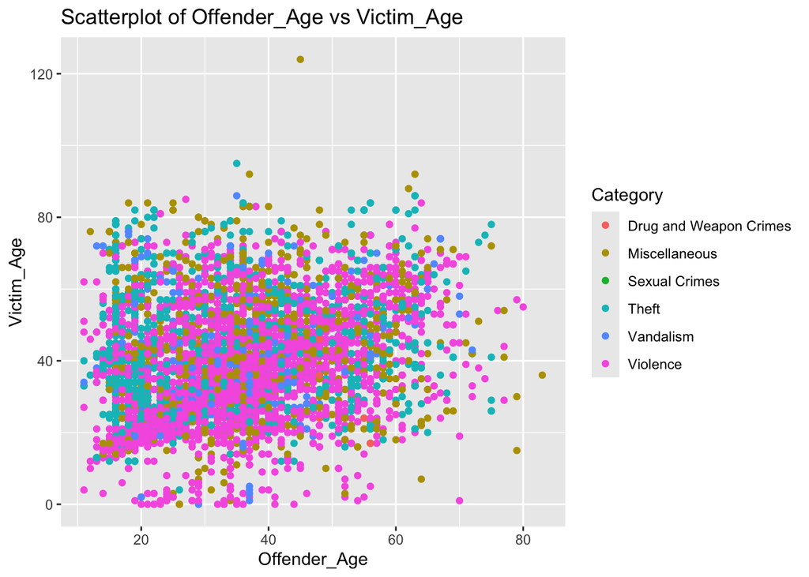

```r
ggplot(crime_data, aes(x = Offender_Age, y = Victim_Age)) +
  geom_point(aes(color = Category)) +
  labs(title = "Scatterplot of Offender_Age vs Victim_Age",
       x = "Offender_Age", y = "Victim_Age")
```

Here we see a scatterplot of the ages of the offenders vs the age of the victims that are also colored by the category of crime that was committed. Just looking at this graph, it is hard to tell whether or not there’s a correlation between the offender’s and the victim’s ages. However, we can see that there are a few outliers in the data. Looking at the coloring, there’s mostly crimes in the category of violence that were committed, but with that being said, there’s no way of inferring a correlation with the category of crime and both or any of the ages present in this data. To conclude, there’s no way of telling exactly by looking at the scatterplot if there’s correlation between the offender’s and the victim’s ages, and if there’s a correlation between the category of crime and the two ages (offender and victim).

Boxplot of Offender_Age vs Offender_Gender

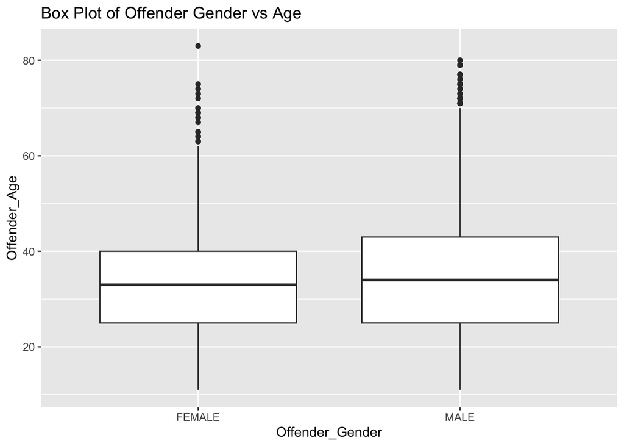

```r
ggplot(crime_data, aes(x = Offender_Gender, y = Offender_Age)) +
  geom_boxplot() +
  labs(title = "Box Plot of Offender Gender vs Age", x = "Offender_Gender",
       "Offender_Age")
```

DATA MANIPULATION

Let’s categorize the offender’s age into age groups and put it in a bar graph to see how many crimes were committed by which age group.

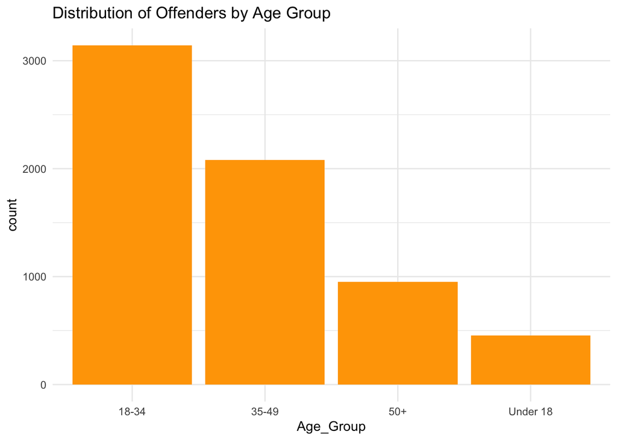

```r
crime_data <- crime_data %>%
  mutate(Age_Group = case_when(
    Offender_Age < 18 ~ "Under 18",
    Offender_Age >= 18 & Offender_Age < 35 ~ "18-34",
    Offender_Age >= 35 & Offender_Age < 50 ~ "35-49",
    Offender_Age >= 50 ~ "50+"
  ))

ggplot(crime_data, aes(x = Age_Group)) +
  geom_bar(fill = "orange") +
  labs(title = "Distribution of Offenders by Age Group") +
  theme_minimal()
```

This new graph gives a pretty interesting insight to this crime data. Yes, we’ve been able to see the ranges of ages of the offenders through a box plot, but this gives us front and center that 18-34 year olds are the most amount of offenders in this dataset. Thanks to this new graph, we’re able to see the clear concentration of offenses among younger individuals, specifically those aged 18-34. This suggests that offenders in this age group are disproportionately represented in the dataset compared to other age groups.

STATISTICAL ANALYSES

Pearson Correlation

```r
cor.test(crime_data$Victim_Age, crime_data$Offender_Age, method = "pearson")
```

```
##
##  Pearson's product-moment correlation
##
## data:  crime_data$Victim_Age and crime_data$Offender_Age
## t = 24.088, df = 6628, p-value < 2.2e-16
## alternative hypothesis: true correlation is not equal to 0
## 95 percent confidence interval:
##  0.2614323 0.3057023
## sample estimates:
##       cor
## 0.2837185
```

Linear Regression

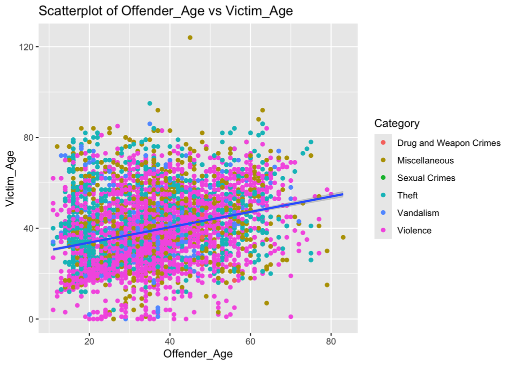

```r
ggplot(crime_data, aes(x = Offender_Age, y = Victim_Age)) +
  geom_point(aes(color = Category)) +
  labs(title = "Scatterplot of Offender_Age vs Victim_Age",
       x = "Offender_Age", y = "Victim_Age") +
  geom_smooth(method = "lm")
```

```r
model <- lm(Offender_Age ~ Victim_Age, data = crime_data)
summary(model)
```

```
##
## Call:
## lm(formula = Offender_Age ~ Victim_Age, data = crime_data)
##
## Residuals:
##     Min      1Q  Median      3Q     Max
## -31.530  -8.538  -1.063   7.175  49.981
##
## Coefficients:
##              Estimate Std. Error t value Pr(>|t|)
## (Intercept) 25.450275   0.410190   62.05   <2e-16 ***
## Victim_Age   0.237898   0.009876   24.09   <2e-16 ***
## ---
## Signif. codes:  0 '***' 0.001 '**' 0.01 '*' 0.05 '.' 0.1 ' ' 1
##
## Residual standard error: 12.28 on 6628 degrees of freedom
## Multiple R-squared:  0.0805, Adjusted R-squared:  0.08036
## F-statistic: 580.2 on 1 and 6628 DF,  p-value: < 2.2e-16
```

T-test to see if there’s a difference in offender ages between victim genders

```r
t.test(Offender_Age ~ Victim_Gender, data = crime_data)
```

```
##
##  Welch Two Sample t-test
##
## data:  Offender_Age by Victim_Gender
## t = -1.3292, df = 5488.4, p-value = 0.1838
## alternative hypothesis: true difference in means between group FEMALE and group MALE is not equal to 0
## 95 percent confidence interval:
##  -1.0651589  0.2043724
## sample estimates:
## mean in group FEMALE   mean in group MALE
##             34.46805             34.89845
```

In order to see if there’s a difference in offender ages between male and female victims, we look at the p-value, which is 0.1838. Since in this case, this p-value is bigger than 0.05, we fail to reject the null hypothesis. In other words there is no significant difference.  
To also support this, the confidence interval [ -1.0651589, 0.2043724] contains a 0 within it, which means there’s no significant difference.

How can you use this dataset to draw conclusions about a larger population? This dataset provides great insights to crime patterns, but in order to generalize its findings into a larger population. We would need to statistically analyze this dataset. Like what we did within this project, inspecting the summary statistics, graphing variables against each other, manipulating data, correlation tests, linear regression, and t-testing will give us various insgihts to many angles within this dataset and others.

CONCLUSION

For Offender_Age vs Offender_Gender Inspecting it’s box plot, we get an idea of the age ranges of male and female offenders. With this graph we concluded that males had a bigger interquartile range than females. Both genders have very similar median age, and females had more outlier ages than men did.

For the Distribution of Offenders by Age Group For this new column that I made, I made age groups for the offenders and sorted them accordingly. Then made a bar graph showing the results, and it was very interesting to see. I found out that in this dataset that 18-34 year olds were the most abundant to committing crimes.